# Lab #3: Data Visualization

Data Science and Society (Sociology 367)

**Lab #3 Markdown File**

**[Lab Instructions](https://dssoc.github.io/assignments/lab_instructions.html)**

In this lab we will practice using the `ggplot2` library to create visualizations of our data. **Our standard for visualizations is that each plot should have axis labels, all labels must be readable to someone unfamiliar with your data (e.g. Female and Male instead of `F` and `M`, Senator and Representative instead of `rep` and `sen`), and we should easily be able to tell what your figure is showing. Failure to do this will result in point deductions.**

See the “Instructions” section of the [Introduction to Lab Assignments](https://dssoc.github.io/assignments/lab_instructions.html) page for more information about the labs. That page also gives descriptions for the datasets we will be using.

**Required reading:**

- [R for Data Science Chapter 13: Relational data](https://r4ds.had.co.nz/relational-data.html)
- [R for Data Science Chapter 3: Data visualization](https://r4ds.had.co.nz/data-visualisation.html)
- [R for Data Science Chapter 28: Graphics for communication](https://r4ds.had.co.nz/graphics-for-communication.html)

**Optional resources:**

- [R for Data Science Chapter 16: Dates and times](https://r4ds.had.co.nz/dates-and-times.html)
- [Grouped, stacked and percent stacked barplot in ggplot2](https://www.r-graph-gallery.com/48-grouped-barplot-with-ggplot2.html)

## Example Questions

**ex1. make a bar chart showing the number of male and female members of congress in our dataset.**

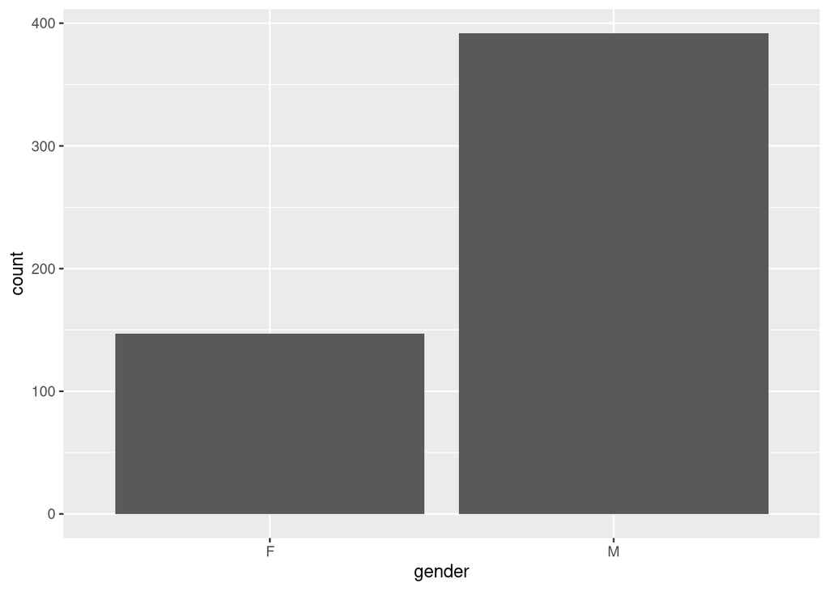

```r
congress %>%
  ggplot(aes(x=gender)) +
    geom_bar()
```

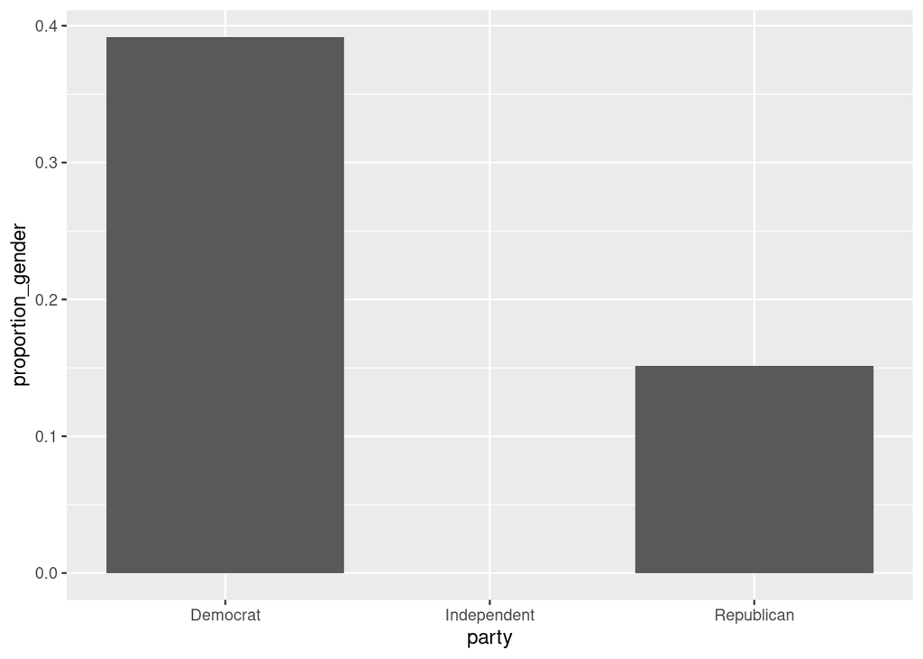

```r
congress %>%
  group_by(party) %>%
  summarize(proportion_gender=mean(gender=='F')) %>%
  ggplot(aes(x=party, y=proportion_gender)) +
    geom_bar(stat='identity', position='dodge')
```